# Predicting Spotify Song Genres from Song Features

Author

Meredith Fraser, Vaibhav Korrapati, Gabriella Angelica Jemima Hasian and Siwei Wang

Published

November 21, 2026

```python
from pathlib import Path

import pandas as pd
import requests

from sklearn.model_selection import train_test_split
from sklearn.preprocessing import StandardScaler
from sklearn.feature_selection import mutual_info_classif
from sklearn.pipeline import make_pipeline
from sklearn.neighbors import KNeighborsClassifier
from sklearn.model_selection import StratifiedKFold, cross_val_score
from sklearn.metrics import accuracy_score

import matplotlib.pyplot as plt
```

## Summary

In this report we ask whether a k-nearest neighbours (k-NN) classification model can use descriptive audio features such as energy, key, mode, and speechiness, amongst others, to accurately predict a genre of the song from one of the following six music genre categories: EDM, latin, pop, R&B, rap and rock. Our tuned k-NN model achieved a test accuracy of 50.56%, indicating that the selected audio features alone are only moderately effective at separating the six genres. Performance was limited by substantial overlap in feature distributions across genres and by the inherently subjective nature of target genre classification labels. Including additional features and testing of alternative models may improve genre prediction.

## Introduction

Digital music collections have expanded rapidly in recent decades, and the recent market shift away from purchase of individual albums towards subscriptions to streaming platforms has significantly changed the way we listen to music (Wlomert et al., 2025). Streaming platforms like Spotify and Apple Music hold tens of millions of songs that can quickly become overwhelming for listeners exploring new music (Spotify ‘For the Record’, 2026; Apple Newsroom Release, 2022; Wlomert et al., 2025). Consequently, classification of defining song characteristics such as genre is increasingly useful for suggesting related songs, and building customized, genre-specific playlists.

Music information retrieval (MIR) is an active area of research, and music genre classification has been identified as a challenging task given the diversity of audio features and the subjective, dynamic definitions of unique genres (Ramirez and Flores, 2020). Previous work on music genre classification has employed several machine learning algorithms, including Support Vector Machines (SVMs), k-Nearest-Neighbour (k-NN) classification algorithms, and has more recently involved advanced deep learning techniques (Narkhede et al., 2022; Ramirez and Flores, 2020). Here, we investigate the effectiveness of a k-NN model and ask whether a k-NN model can predict a candidate genre for songs based on various song features. We selected a k-NN model based on its simplicity and interpretability for predicting the genre of future related songs.

In our study, we use Spotify song data (R for Data Science Online Learning Community, 2020) collected from the Spotify Web API using the spotifyr package (Thompson et al., 2024). This data set contains total 28,356 unique songs, each with twelve numeric audio descriptive features. These features include:

1. danceability (scale of 0-1, based on a combination of musical elements);
2. energy (scale of 0-1, based on measure of intensity and activity);
3. key (ordinal integer based on standard pitch Class notation that measures the estimated overall key of the track);
4. loudness (measures the overall loudness of the track in decibels, dB);
5. mode (indicates the modality if song is in major (1) or minor (0));
6. speechiness (a measure of the presence of spoken words in a song, ranging from 0-1);
7. acousticness (a confidence level of whether the track is acoustic, ranging from 0-1);
8. instrumentalness (measure of whether a track contains no vocals, ranging from 0-1);
9. liveness (measure of the presence of a live audience in the song recording, ranging from 0-1);
10. valence (measure describing the musical positiveness conveyed by the song, ranging from 0-1);
11. tempo (estimated tempo of the song in beats per minute, bpm); and
12. duration (duration of the song in milliseconds, ms).

The target we aim to predict is a candidate playlist genre for the song, one of EDM, latin, pop, R&B, rap and rock, determined from existing user-created and Spotify playlists that contain these songs.

## Methods

We used a K-Nearest Neighbors (KNN) classifier to predict a song’s playlist genre based on its audio features. KNN works by identifying songs with similar feature values and using their genres to make a prediction, making it a suitable approach for exploring whether songs with similar audio characteristics tend to belong to the same genre. Rather than learning a fixed relationship between each feature and genre, the model relies on similarities between songs, which aligns with our question of whether audio features can help distinguish musical genres.

We evaluated the model using accuracy, which represents the proportion of songs correctly classified out of all predictions. We chose accuracy because it provides an intuitive measure of the model’s overall performance across the genre categories. To determine the best-performing configuration, we used cross-validation on the training data to compare different feature subsets and values of k, then selected the combination with the highest mean cross-validation accuracy. Finally, we evaluated the selected model on the held-out test set to assess how well it generalized to unseen songs.

### Data download and cleaning

We downloaded the Spotify Songs dataset from TidyTuesday. Because each row represents a single playlist entry, songs that appear on multiple playlists are listed more than once.

```python
DATA_URL = (
    "https://raw.githubusercontent.com/rfordatascience/tidytuesday/main/"
    "data/2020/2020-01-21/spotify_songs.csv"
)
RAW_DIR = Path("../data/raw")
PROCESSED_DIR = Path("../data/processed")
RAW_DIR.mkdir(parents=True, exist_ok=True)
PROCESSED_DIR.mkdir(parents=True, exist_ok=True)

raw_path = RAW_DIR / "spotify_songs.csv"
response = requests.get(DATA_URL, timeout=60)
response.raise_for_status()
raw_path.write_bytes(response.content)

spotify_raw = pd.read_csv(raw_path)
spotify_raw.shape
```

```
(32833, 23)
```

To prepare and clean the dataset, we kept only the columns needed for modelling: each song’s ID, title, artist, playlist genre (our target), and Spotify’s twelve numeric audio features (such as energy and tempo). Duplicate entries could put the same song in both the training and test sets and make a test score look better than it is. To prevent data leakage of this sort, we retain only the first occurrence of each song.

```python
FEATURES = [
    "danceability",
    "energy",
    "key",
    "loudness",
    "mode",
    "speechiness",
    "acousticness",
    "instrumentalness",
    "liveness",
    "valence",
    "tempo",
    "duration_ms",
]
TARGET = "playlist_genre"

spotify_clean = (
    spotify_raw[["track_id", "track_name", "track_artist", TARGET] + FEATURES]
    .drop_duplicates(subset="track_id", keep="first")
    .dropna(subset=[TARGET] + FEATURES)
    .reset_index(drop=True)
)
spotify_clean.to_csv(PROCESSED_DIR / "spotify_songs_clean.csv", index=False)

print(f"Rows before cleaning: {len(spotify_raw):,}")
print(f"Rows after cleaning: {len(spotify_clean):,}")
```

```
Rows before cleaning: 32,833
Rows after cleaning: 28,356
```

### Train/test split

Before exploring the data or making any modelling decisions, we set aside 20% of the songs as a test set and kept the remaining 80% for training. We split the data so that each genre makes up the same share of both sets, and locked in the random split with a fixed seed (522) to make the process reproducible with the same test split. The test set will be untouched until we evaluate our final model.

```python
train_df, test_df = train_test_split(
    spotify_clean,
    test_size=0.2,
    stratify=spotify_clean[TARGET],
    random_state=522,
)
train_df.to_csv(PROCESSED_DIR / "spotify_train.csv", index=False)
test_df.to_csv(PROCESSED_DIR / "spotify_test.csv", index=False)

print(f"Training set: {len(train_df):,} songs")
print(f"Test set: {len(test_df):,} songs")
```

```
Training set: 22,684 songs
Test set: 5,672 songs
```

### Exploratory data analysis

#### Summary of Training Data

We explored the training set to understand the distribution of playlist genres and the audio features used for classification. Only training data was used to avoid influencing the analysis with information from the test set.

```python
from IPython.display import display

print(f"Training set: {train_df.shape[0]:,} songs")
print(f"Number of playlist genres: {train_df[TARGET].nunique()}")
print(f"Missing values: {train_df[FEATURES + [TARGET]].isna().sum().sum()}")
```

```
Training set: 22,684 songs
Number of playlist genres: 6
Missing values: 0
```

**Table 1. Distribution of playlist genres in the training set.**

```python
genre_summary = (
    train_df[TARGET]
    .value_counts()
    .rename_axis("Playlist genre")
    .reset_index(name="Number of songs")
)

genre_summary["Percentage (%)"] = (
    genre_summary["Number of songs"] / len(train_df) * 100
).round(1)

display(genre_summary)
```

|  | Playlist genre | Number of songs | Percentage (%) |
| --- | --- | --- | --- |
| 0 | rap | 4321 | 19.0 |
| 1 | pop | 4105 | 18.1 |
| 2 | edm | 3901 | 17.2 |
| 3 | r&b | 3603 | 15.9 |
| 4 | rock | 3444 | 15.2 |
| 5 | latin | 3310 | 14.6 |

Table 1 shows the distribution of songs across six playlist genres in the training set. Rap has the most songs (19.0%), while Latin has the fewest (14.6%). Overall, the genre distribution is relatively balanced, with no single genre dominating the dataset.

**Table 2. Descriptive statistics of continuous audio features in the training set.**

```python
continuous_features = [
    feature for feature in FEATURES
    if feature not in ["key", "mode"]
]

audio_data = train_df[continuous_features].copy()
audio_data["duration_ms"] = audio_data["duration_ms"] / 1000
audio_data = audio_data.rename(
    columns={"duration_ms": "duration (seconds)"}
)

feature_summary = (
    audio_data
    .agg(["mean", "std", "min", "max"])
    .T
    .rename(columns={
        "mean": "Mean",
        "std": "SD",
        "min": "Min",
        "max": "Max"
    })
    .rename_axis("Audio feature")
    .reset_index()
    .round(3)
)

display(feature_summary)
```

|  | Audio feature | Mean | SD | Min | Max |
| --- | --- | --- | --- | --- | --- |
| 0 | danceability | 0.653 | 0.146 | 0.000 | 0.983 |
| 1 | energy | 0.698 | 0.184 | 0.000 | 1.000 |
| 2 | loudness | -6.827 | 3.046 | -46.448 | 1.135 |
| 3 | speechiness | 0.108 | 0.102 | 0.000 | 0.877 |
| 4 | acousticness | 0.177 | 0.223 | 0.000 | 0.994 |
| 5 | instrumentalness | 0.091 | 0.232 | 0.000 | 0.994 |
| 6 | liveness | 0.191 | 0.156 | 0.000 | 0.996 |
| 7 | valence | 0.510 | 0.234 | 0.000 | 0.990 |
| 8 | tempo | 120.931 | 27.013 | 0.000 | 239.440 |
| 9 | duration (seconds) | 226.640 | 61.173 | 4.000 | 517.810 |

Table 2 summarizes the continuous audio features in the training set. Songs have an average danceability of 0.653, energy of 0.698, and tempo of approximately 121 BPM. The features have different measurement scales, especially tempo and duration compared to features ranging from 0 to 1. Therefore, feature scaling is important before applying KNN classification. Key and mode were excluded from this summary because they are discrete variables.

#### **Visualization of Training Data**

We created two visualizations using only the training data to explore the genre distribution and differences in audio features.

```python
import altair as alt

genre_chart = (
    alt.Chart(genre_summary)
    .mark_bar()
    .encode(
        x=alt.X("Playlist genre:N", sort="-y", title="Playlist genre"),
        y=alt.Y("Number of songs:Q", title="Number of songs"),
        tooltip=["Playlist genre:N", "Number of songs:Q"]
    )
    .properties(
        width=600,
        height=350,
        title="Distribution of Playlist Genres"
    )
)

display(genre_chart)
```

[interactive chart not shown]

Figure 1: Number of songs in each playlist genre in the training set.

Figure 1 shows the distribution of playlist genres in the training set. Rap has the most songs (4,321), while Latin has the fewest (3,310). Overall, the six genres are relatively balanced, with no single genre dominating the training set.

```python
alt.data_transformers.disable_max_rows()

energy_chart = (
    alt.Chart(train_df[[TARGET, "energy"]])
    .mark_boxplot()
    .encode(
        x=alt.X(
            "playlist_genre:N",
            title="Playlist genre",
            sort=genre_summary["Playlist genre"].tolist()
        ),
        y=alt.Y(
            "energy:Q",
            title="Energy (0–1)",
            scale=alt.Scale(domain=[0, 1])
        )
    )
    .properties(
        width=600,
        height=350,
        title="Energy Distribution by Playlist Genre"
    )
)

display(energy_chart)
```

[interactive chart not shown]

Figure 2: Distribution of song energy across playlist genres in the training set.

Figure 2 compares the energy distributions across the six playlist genres. EDM has the highest median energy, while R&B has the lowest. However, the distributions overlap across genres, suggesting that energy alone may not be enough to classify songs accurately. Combining multiple audio features may help improve KNN classification.

```python
import numpy as np

# Prepare the continuous audio features
plot_features = [f for f in FEATURES if f not in ["key", "mode"]]

plot_data = train_df[plot_features].copy()
plot_data["duration_ms"] = plot_data["duration_ms"] / 1000
plot_data = plot_data.rename(
    columns={"duration_ms": "duration (seconds)"}
)

# Calculate distribution frequencies for each feature
histogram_rows = []

for feature in plot_data.columns:
    values = plot_data[feature].dropna()
    counts, edges = np.histogram(values, bins=25)

    for i in range(len(counts)):
        histogram_rows.append({
            "feature": feature,
            "bin_center": (edges[i] + edges[i + 1]) / 2,
            "count": counts[i]
        })

histogram_df = pd.DataFrame(histogram_rows)

# Create individual area plots with independent axes
charts = []

for feature in plot_data.columns:
    feature_hist = histogram_df[
        histogram_df["feature"] == feature
    ]

    chart = (
        alt.Chart(feature_hist)
        .mark_area(opacity=0.7)
        .encode(
            x=alt.X("bin_center:Q", title="Feature value"),
            y=alt.Y("count:Q", title="Number of songs")
        )
        .properties(
            width=250,
            height=130,
            title=feature
        )
    )

    charts.append(chart)

# Arrange plots in 2 columns
rows = [
    alt.hconcat(charts[i], charts[i + 1])
    for i in range(0, len(charts), 2)
]

feature_chart = alt.vconcat(*rows)

display(feature_chart)
```

[interactive chart not shown]

Figure 3: Distributions of continuous audio features in the training set.

Figure 3 shows the distributions of the continuous audio features in the training set. Most songs have relatively high danceability and energy, while speechiness, acousticness, and instrumentalness are strongly right-skewed, with many values close to zero. Tempo is mostly concentrated around 100–150 BPM, and song duration is generally around 150–300 seconds. The features also have very different scales, highlighting the importance of feature scaling before KNN classification.

### Classification analysis

We defined playlist_genre as our target variable and selected 12 numerical audio features as predictors. These features capture different characteristics of a song, including its rhythmic properties, energy, tonal attributes, and duration. We then separated the predictors and target labels for both the training and test sets, providing the inputs needed for feature selection, model training, and evaluation.

```python
X_train = train_df[FEATURES]
y_train = train_df[TARGET]

X_test = test_df[FEATURES]
y_test = test_df[TARGET]
```

We then used Mutual Information to rank the 12 audio features based on how informative they were for predicting playlist genre. Continuous features were treated as continuous variables, while key and mode were treated as discrete features since they represent musical categories rather than continuous measurements. This ranking allowed us to identify the most informative audio features and investigate whether using a smaller subset of predictors could improve classification performance.

```python
# Standardize training features for feature ranking
scaler = StandardScaler()
X_train_scaled = scaler.fit_transform(X_train)

# Mutual Information scores
mi_scores = mutual_info_classif(
    X_train_scaled,
    y_train,
    discrete_features=[
        False, False, True, False, True, False,
        False, False, False, False, False, False
    ],
    random_state=42
)

# Rank features
feature_ranking = pd.DataFrame({
    "feature": FEATURES,
    "mi_score": mi_scores
}).sort_values(
    "mi_score", ascending=False
).reset_index(drop=True)

feature_ranking
```

|  | feature | mi_score |
| --- | --- | --- |
| 0 | tempo | 0.266897 |
| 1 | speechiness | 0.136772 |
| 2 | danceability | 0.114058 |
| 3 | duration_ms | 0.106998 |
| 4 | energy | 0.098432 |
| 5 | acousticness | 0.094129 |
| 6 | instrumentalness | 0.092599 |
| 7 | loudness | 0.069897 |
| 8 | valence | 0.046887 |
| 9 | key | 0.014644 |
| 10 | liveness | 0.012065 |
| 11 | mode | 0.007922 |

After ranking the features, we grouped them into subsets of the top 3, 5, and 8 features, along with the full set of 12 features. This allowed us to compare whether using fewer, more informative features could improve classification accuracy, or whether including additional audio characteristics would provide more useful information to the model.

```python
ranked_features = feature_ranking["feature"].tolist()

feature_subsets = {
    "Top 3": ranked_features[:3],
    "Top 5": ranked_features[:5],
    "Top 8": ranked_features[:8],
    "All 12": ranked_features
}
```

We then used stratified 5-fold cross-validation to compare KNN models across the four feature subsets and different values of *k*, ranging from 3 to 200. Since KNN relies on distances between observations, we included StandardScaler in each model pipeline to standardize the features, preventing variables with larger numerical scales, such as duration and tempo, from dominating the distance calculations. Stratification maintained the genre proportions across folds, while shuffling and a fixed random seed (522) ensured reproducibility. For each combination of feature subset and *k*, we recorded the mean and standard deviation of accuracy across the five folds to compare model performance and identify the most promising configuration.

```python
# 5-fold cross-validation
cv = StratifiedKFold(
    n_splits=5,
    shuffle=True,
    random_state=522
)

# Candidate values for k
k_values = range(3, 201, 5)

cv_results = []

for subset_name, subset_features in feature_subsets.items():

    for k in k_values:

        model = make_pipeline(
            StandardScaler(),
            KNeighborsClassifier(n_neighbors=k)
        )

        scores = cross_val_score(
            model,
            X_train[subset_features],
            y_train,
            cv=cv,
            scoring="accuracy",
            n_jobs=-1
        )

        cv_results.append({
            "feature_subset": subset_name,
            "n_features": len(subset_features),
            "k": k,
            "mean_cv_accuracy": scores.mean(),
            "std_cv_accuracy": scores.std()
        })

cv_results_df = pd.DataFrame(cv_results)

# Sort by mean CV accuracy
cv_results_df = cv_results_df.sort_values(
    "mean_cv_accuracy",
    ascending=False
).reset_index(drop=True)

# Best configuration
cv_results_df.head(1)
```

|  | feature_subset | n_features | k | mean_cv_accuracy | std_cv_accuracy |
| --- | --- | --- | --- | --- | --- |
| 0 | Top 8 | 8 | 103 | 0.503615 | 0.011107 |

We compared the mean cross-validation accuracy across the four feature subsets and different values of *k* using a heatmap. This visualization allows us to examine how the number of features and neighbors affect model performance and identify the configurations that achieve the highest accuracy, which can guide further tuning.

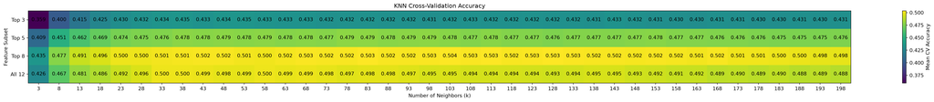

```python
heatmap_data = cv_results_df.pivot(
    index="feature_subset",
    columns="k",
    values="mean_cv_accuracy"
)

heatmap_data = heatmap_data.reindex(
    ["Top 3", "Top 5", "Top 8", "All 12"]
)

plt.figure(figsize=(30, 3))

plt.imshow(heatmap_data, aspect="auto")

plt.xticks(range(len(heatmap_data.columns)), heatmap_data.columns)
plt.yticks(range(len(heatmap_data.index)), heatmap_data.index)

plt.xlabel("Number of Neighbors (k)")
plt.ylabel("Feature Subset")
plt.title("KNN Cross-Validation Accuracy")

for i in range(len(heatmap_data.index)):
    for j in range(len(heatmap_data.columns)):
        plt.text(
            j, i,
            f"{heatmap_data.iloc[i, j]:.3f}",
            ha="center",
            va="center"
        )

plt.colorbar(label="Mean CV Accuracy")
plt.tight_layout()
plt.show()
```

The Top 8 feature subset generally achieved the highest cross-validation accuracy, outperforming the Top 3 and Top 5 subsets across most values of *k*. Its accuracy increased as the number of neighbors grew before plateauing at approximately 50.1%–50.4%. Although the All 12 feature subset also performed competitively, it did not consistently outperform Top 8, suggesting that additional features did not improve classification performance. We therefore focused on the Top 8 subset and the larger values of *k*, conducting a finer search between 98 and 107 across all feature subsets to compare neighboring configurations and identify the best-performing model.

```python
# 5-fold cross-validation
cv = StratifiedKFold(
    n_splits=5,
    shuffle=True,
    random_state=522
)

# Fine search for k
k_values = range(98, 108, 1)

fine_cv_results = []

for subset_name, subset_features in feature_subsets.items():

    for k in k_values:

        model = make_pipeline(
            StandardScaler(),
            KNeighborsClassifier(n_neighbors=k)
        )

        scores = cross_val_score(
            model,
            X_train[subset_features],
            y_train,
            cv=cv,
            scoring="accuracy",
            n_jobs=-1
        )

        fine_cv_results.append({
            "feature_subset": subset_name,
            "n_features": len(subset_features),
            "k": k,
            "mean_cv_accuracy": scores.mean(),
            "std_cv_accuracy": scores.std()
        })

fine_cv_results_df = pd.DataFrame(fine_cv_results)

# Sort by mean CV accuracy
fine_cv_results_df = fine_cv_results_df.sort_values(
    "mean_cv_accuracy",
    ascending=False
).reset_index(drop=True)

# Best configuration
fine_cv_results_df.head(1)
```

|  | feature_subset | n_features | k | mean_cv_accuracy | std_cv_accuracy |
| --- | --- | --- | --- | --- | --- |
| 0 | Top 8 | 8 | 103 | 0.503615 | 0.011107 |

```python
final_features = feature_subsets["Top 8"]
final_k = 103

final_knn = make_pipeline(
    StandardScaler(),
    KNeighborsClassifier(n_neighbors=final_k)
)

final_knn.fit(X_train[final_features], y_train)

y_pred = final_knn.predict(X_test[final_features])

test_accuracy = accuracy_score(y_test, y_pred)

print(f"Test Accuracy: {test_accuracy:.4f}")
```

```
Test Accuracy: 0.5056
```

Using the selected Top 8 feature subset and (*k* = 103), we fitted the final KNN model on the full training set and evaluated it on the held-out test set. The model achieved a test accuracy of **50.56%**, correctly classifying approximately half of the songs. This indicates that the selected audio features provide some predictive information about playlist genre, but are not sufficient to reliably distinguish between all genres.

## Results

To further examine model performance, we evaluated its predictions across individual genres using precision, recall, and F1-score. This allows us to identify which genres were more accurately classified and which were more challenging for the model to distinguish.

```python
from sklearn.metrics import classification_report
import pandas as pd

report = classification_report(
    y_test,
    y_pred,
    output_dict=True
)

report_df = pd.DataFrame(report).transpose()

genre_metrics = report_df.loc[
    sorted(y_test.unique()),
    ["precision", "recall", "f1-score"]
]

genre_metrics
```

|  | precision | recall | f1-score |
| --- | --- | --- | --- |
| edm | 0.549958 | 0.671107 | 0.604522 |
| latin | 0.484375 | 0.374849 | 0.422631 |
| pop | 0.375502 | 0.364167 | 0.369748 |
| r&b | 0.454009 | 0.427303 | 0.440252 |
| rap | 0.555649 | 0.614815 | 0.583736 |
| rock | 0.598504 | 0.557491 | 0.577270 |

The model’s performance varied considerably across genres. EDM achieved the highest recall (67.11%) and F1-score (60.45%), followed by rap, indicating that these genres were relatively easier for the model to identify. Rock had the highest precision (59.85%), suggesting that its predictions were comparatively reliable. In contrast, pop had the lowest F1-score (36.97%), while Latin also showed relatively low recall (37.48%). These differences suggest that the selected audio features may capture characteristics of certain genres more effectively than others.

We also compared the actual genre distribution in the test set with the distribution of genres predicted by the model. This comparison helps identify whether the model tends to favor certain genres or systematically underpredicts others.

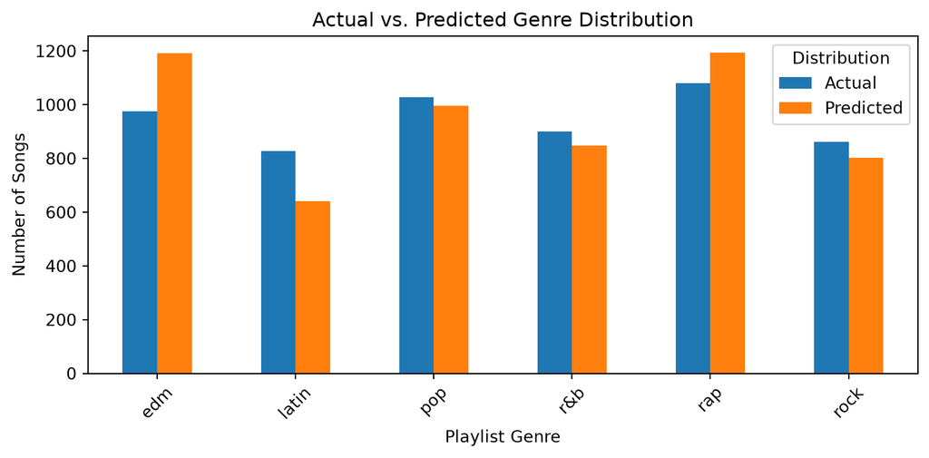

```python
import matplotlib.pyplot as plt
import numpy as np

actual_counts = y_test.value_counts().sort_index()
predicted_counts = pd.Series(y_pred).value_counts().sort_index()

distribution_df = pd.DataFrame({
    "Actual": actual_counts,
    "Predicted": predicted_counts
}).fillna(0)

distribution_df.plot(
    kind="bar",
    figsize=(8, 4)
)

plt.xlabel("Playlist Genre")
plt.ylabel("Number of Songs")
plt.title("Actual vs. Predicted Genre Distribution")
plt.xticks(rotation=45)
plt.legend(title="Distribution")
plt.tight_layout()
plt.show()
```

The predicted genre distribution differed from the actual distribution in the test set. EDM and rap were overpredicted, while Latin was notably underpredicted. The model predicted approximately 1,190 EDM songs compared with fewer than 1,000 actual songs, while the number of predicted Latin songs was substantially lower than the actual count. Although the predicted counts for pop, R&B, and rock were relatively close to their actual distributions, this does not necessarily indicate accurate classification at the individual-song level. These discrepancies highlight differences in prediction behavior across genres and may help explain the uneven classification performance observed.

## Discussion

In this analysis, we found that it is difficult to accurately predict music genre from 12 numerical audio features alone. These results suggest that audio features alone are not always sufficient for reliable genre classification, and consideration of other additional information and song metadata may be needed to accurately predict genre classification. However, despite its moderate accuracy score, this k-NN model could still support rough suggestions for similar genres when building playlists or recommending related songs.

Our final k-NN model achieved a final accuracy score of 50.56% on the test dataset. This score was lower than expected, and the optimum number of neighbours (k=103) was unexpectedly high. In this case, a large k likely reflects heavily overlapping genre classes amongst the examined 8 features, leading to averaging over many neighbours to reduce overfitting to individual nearby songs. However, results show that prediction scores varied across genres, potentially indicating more unique audio feature values for genres such as EDM and rap compared to other genres. To improve on this model, future work could include additional features not included in the current analysis, such as song title or artist, and testing of alternative model approaches such as Support Vector Machines (SVM) which have shown success for music genre classification in the field of music information retrieval (MIR) (Ramirez and Flores, 2020).

A key assumption of this analysis is that the provided target genres are an accurate representation of the true genre of the songs used in both training and testing. However, this was ultimately influenced by our initial decision to keep only the first occurrence of songs that were classified to multiple different genres, which itself illustrates the difficulty of defining one specific genre for any given song. Music genres are inherently subjective labels that can be vary across listeners and over time. Because all our data came from a single streaming service (Spotify) and was collected in one specific time range (2020-2021), this model may not generalize well to music genre classification from other time ranges or streaming platforms.

Overall, music genres can often have intersecting boundaries, and the overlapping audio features revealed in this analysis, makes for a difficult classification task. The findings of this analysis highlight that genre is a dynamic, context-dependent label rather than a fixed characteristic of a given song. Model predicted genres should therefore be treated as suggestions rather than definitive categories, and streaming services should be cautious of relying on models exclusively given how they could affect artist exposure or listener recommendations.

## References

Apple Newsroom Release. (October 3, 2022). “Celebrating 100 million songs”. Accessed on 20-Nov-2026: https://www.apple.com/ca/newsroom/2022/10/celebrating-100-million-songs/

Narkhede, N., Mathur, S., Bhaskar, A. (2022). Machine Learning Techniques for Music Genre Classification. In: Joshi, A., Mahmud, M., Ragel, R.G., Thakur, N.V. (eds) Information and Communication Technology for Competitive Strategies (ICTCS 2020). Lecture Notes in Networks and Systems, vol 191. Springer, Singapore. https://doi.org/10.1007/978-981-16-0739-4_15

R for Data Science Online Learning Community. (2020). Spotify songs [Data set]. TidyTuesday. https://github.com/rfordatascience/tidytuesday/tree/main/data/2020/2020-01-21

Ramirez, J., & Flores, M. J. (2020). Machine learning for music genre: multifaceted review and experimentation with audioset. Journal of Intelligent Information Systems, 55(3), 469-499. https://doi.org/10.1007/s10844-019-00582-9

Thompson C, Antal D, Parry J, Phipps D, Wolff T (2024). spotifyr: R Wrapper for the ‘Spotify’ Web API. doi: 10.32614/CRAN.package.spotifyr. R package version 2.2.5, https://CRAN.R-project.org/package=spotifyr.

Spotify For the Record. (Accessed 20-Nov-2026). “About Spotify”. https://newsroom.spotify.com/company-info/

Wlomert, N., Papies, D., & van Heerde, H. J. (2025). Driving Music Demand in the Age of Streaming: Understanding the Heterogeneity in Curated Playlist Effectiveness. Journal of Marketing, 0(0). https://doi.org/10.1177/00222429251395986